# Introduction

Distributing samples to wells plates for experimental procedures is a very common task. In the following we use a data set of longitudinal subject samples that are to be spread across several n-well plates, balanced for treatment group and time point `longitudinal_subject_samples`.

```r
data("longitudinal_subject_samples")
head(longitudinal_subject_samples)
```

```
#> # A tibble: 6 × 9
#>   SampleID SampleType SubjectID Group  Week Sex     Age   BMI SamplesPerSubject
#>   <chr>    <fct>      <chr>     <chr> <dbl> <chr> <dbl> <dbl>             <dbl>
#> 1 P01W1    Sample     P01       1         1 F        71  28.1                 7
#> 2 P01W4    Sample     P01       1         4 F        71  28.1                 7
#> 3 P01W6    Sample     P01       1         6 F        71  28.1                 7
#> 4 P01W10   Sample     P01       1        10 F        71  28.1                 7
#> 5 P01W14   Sample     P01       1        14 F        71  28.1                 7
#> 6 P01W18   Sample     P01       1        18 F        71  28.1                 7
```

In the fist example we’ll use a subset of samples to demonstrate the process.

```r
dat <- longitudinal_subject_samples |>
  filter(Group %in% 1:5, Week %in% c(1, 4)) |>
  select(SampleID, SubjectID, Group, Sex, Week)

# for simplicity: remove two subjects that don't have both visits
dat <- dat |>
  group_by(SubjectID) |>
  filter(n() == 2) |>
  ungroup()
```

# Layout optimization in one go

For placing samples on plates and optimizing across plate distribution of factors as well as the within plate spacial distribution, the `multi_plate_wrapper()` function can be used. It focuses first on assigning samples to plates and then optimizes the layout within plates.

We do the initial assignment of sample to plates and plot it

```r
set.seed(42)

bc <- BatchContainer$new(
  dimensions = list("plate" = 3, "row" = 4, "col" = 6),
)

bc <- assign_in_order(bc, dat)

head(bc$get_samples()) |> gt::gt()
```

| plate | row | col | SampleID | SubjectID | Group | Sex | Week |
| --- | --- | --- | --- | --- | --- | --- | --- |
| 1 | 1 | 1 | P01W1 | P01 | 1 | F | 1 |
| 1 | 1 | 2 | P01W4 | P01 | 1 | F | 4 |
| 1 | 1 | 3 | P02W1 | P02 | 1 | M | 1 |
| 1 | 1 | 4 | P02W4 | P02 | 1 | M | 4 |
| 1 | 1 | 5 | P03W1 | P03 | 1 | M | 1 |
| 1 | 1 | 6 | P03W4 | P03 | 1 | M | 4 |

We can view the initial assignment with `plot_plate`

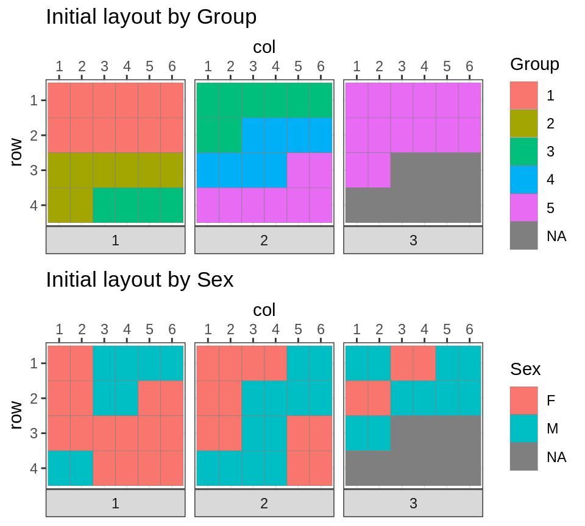

```r
cowplot::plot_grid(
  plotlist = list(
    plot_plate(bc,
      plate = plate, row = row, column = col, .color = Group,
      title = "Initial layout by Group"
    ),
    plot_plate(bc,
      plate = plate, row = row, column = col, .color = Sex,
      title = "Initial layout by Sex"
    )
  ),
  nrow = 2
)
```

For optimization `optimize_multi_plate_design()` iteratively calls `optimize_design()` for different steps of the experiment. For across plate optimization osat scoring is used. For within plate optimization spatial scoreing is used. The order of the factors indicate their relative importance. In this case we prioritize Group over Sex.

```r
bc <- optimize_multi_plate_design(bc,
  across_plates_variables = c("Group", "Sex"),
  within_plate_variables = c("Group"),
  plate = "plate",
  row = "row",
  column = "col",
  n_shuffle = 2,
  max_iter = 700,
  quiet = TRUE
)

```

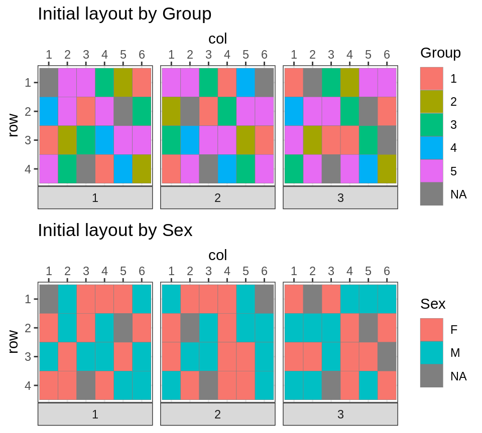

```r
cowplot::plot_grid(
  plotlist = list(
    plot_plate(bc,
      plate = plate, row = row, column = col, .color = Group,
      title = "Initial layout by Group"
    ),
    plot_plate(bc,
      plate = plate, row = row, column = col, .color = Sex,
      title = "Initial layout by Sex"
    )
  ),
  nrow = 2
)
```

We can look at the trace objects for each internal `optimize_design` run, returned from the wrapper function.

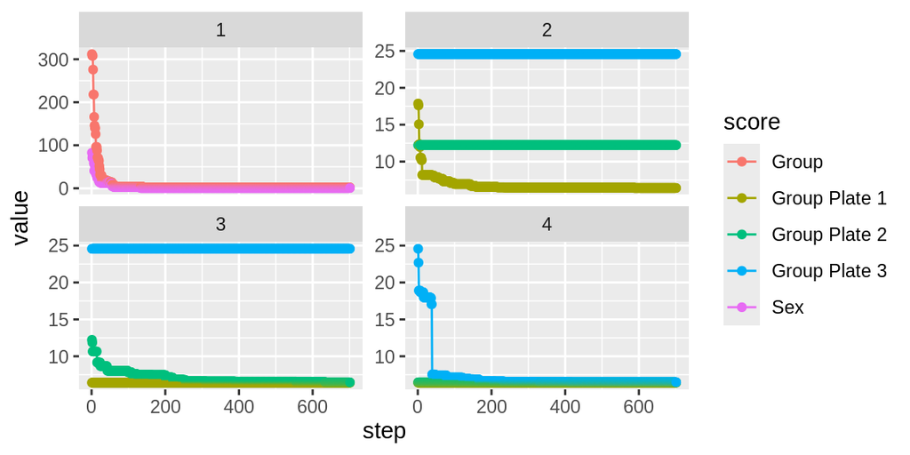

```r
bc$scores_table() |>
  ggplot(aes(step, value, color = score)) +
  geom_line() +
  geom_point() +
  facet_wrap(~ optimization_index, scales = "free_y")
```

## Plate scoring

Note that internally the wrapper function sets up plate specific scoring functions that could manually be set up in the following way.

```r
scoring_f <- c(
  Group = mk_plate_scoring_functions(bc,
    plate = "plate", row = "row", column = "col",
    group = "Group", penalize_lines = "hard"
  ),
  Sex = mk_plate_scoring_functions(bc,
    plate = "plate", row = "row", column = "col",
    group = "Sex", penalize_lines = "hard"
  )
)
```

For more information on customized plate scoring see vignette `Plate scoring examples`.

# Two step approach

Sometimes layout requests can be more complicated. Assume we want to keep the two samples of a subject on the same 24 well plate.

Now we need to customize across plate optimization more so we need to split the process into two steps.

## Step 1: Subjects to plates

There are 31 subjects with each 2 time points, i.e. we need ~ 11 subjects per plate and want to balance by treatment, sex.

First we create a batch container with 3 batches that each fit 11 subjects i.e. have 11 virtual `locations`.

For layout scoring we use OSAT score on `Group` and `Sex` variables.

Then we assign the samples randomly to the batches and look at their initial distribution.

```r
set.seed(17) # gives `bad` random assignment

bc <- BatchContainer$new(
  dimensions = list("batch" = 3, "location" = 11)
)

scoring_f <- list(
  group = osat_score_generator(batch_vars = "batch", feature_vars = "Group"),
  sex = osat_score_generator(batch_vars = "batch", feature_vars = "Sex")
)

bc <- assign_random(
  bc,
  dat |> select(SubjectID, Group, Sex) |> distinct()
)

bc$get_samples() |>
  head() |>
  gt::gt()
```

| batch | location | SubjectID | Group | Sex |
| --- | --- | --- | --- | --- |
| 1 | 1 | NA | NA | NA |
| 1 | 2 | P32 | 5 | M |
| 1 | 3 | P10 | 3 | F |
| 1 | 4 | P26 | 3 | M |
| 1 | 5 | P17 | 5 | M |
| 1 | 6 | P07 | 2 | F |

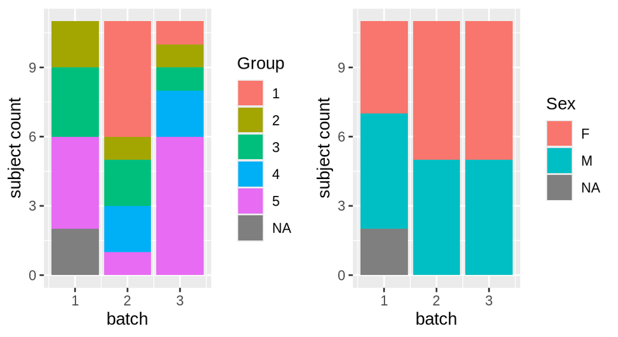

```r
cowplot::plot_grid(
  plotlist = list(
    bc$get_samples() |> ggplot(aes(x = batch, fill = Group)) +
      geom_bar() +
      labs(y = "subject count"),
    bc$get_samples() |> ggplot(aes(x = batch, fill = Sex)) +
      geom_bar() +
      labs(y = "subject count")
  ),
  nrow = 1
)
```

Optimizing the layout with `optimize_design()`

```r
bc <- optimize_design(
  bc,
  scoring = scoring_f,
  n_shuffle = 1,
  acceptance_func = ~ accept_leftmost_improvement(..., tolerance = 0.01),
  max_iter = 150,
  quiet = TRUE
)

```

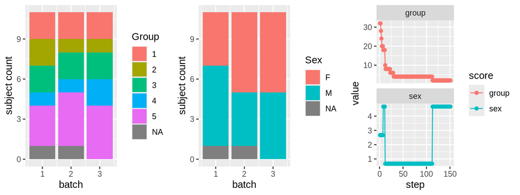

```r
cowplot::plot_grid(
  plotlist = list(
    bc$get_samples() |> ggplot(aes(x = batch, fill = Group)) +
      geom_bar() +
      labs(y = "subject count"),
    bc$get_samples() |> ggplot(aes(x = batch, fill = Sex)) +
      geom_bar() +
      labs(y = "subject count"),
    bc$plot_trace(include_aggregated = TRUE)
  ),
  ncol = 3
)
```

## Step 2: Within plate sample distribution

Using the result from step 1 we now optimize the layout within plates. For this we still need to add empty wells to each batch and assign the pre-allocated sample sheet in the right way to the new batch container.

```r
dat <- dat |>
  left_join(bc$get_samples() |>
    select(SubjectID, batch))
```

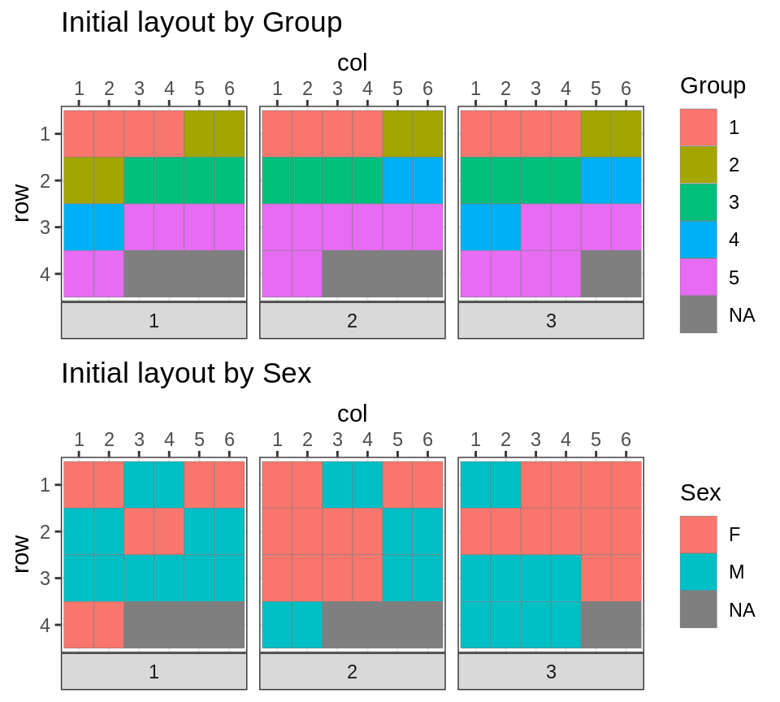

```r
# add empty wells depending on how full the batch plate is
dat <- dat |>
  bind_rows(data.frame(
    SubjectID = "empty",
    SampleID = paste("empty", 1:(3 * 24 - nrow(dat))),
    batch = rep(1:3, 24 - (dat |> count(batch) |> pull(n)))
  ))

bc <- BatchContainer$new(
  dimensions = list("plate" = 3, "row" = 4, "col" = 6)
)

# initial assignment such that the original plate assigned stays the same
bc <- assign_in_order(
  bc,
  dat |> arrange(batch)
)


cowplot::plot_grid(
  plotlist = list(
    plot_plate(bc,
      plate = plate, row = row, column = col, .color = Group,
      title = "Initial layout by Group"
    ),
    plot_plate(bc,
      plate = plate, row = row, column = col, .color = Sex,
      title = "Initial layout by Sex"
    )
  ),
  nrow = 2
)
```

As we have already assigned samples to plates, the across plate optimization can be skipped in the wrapper. For distributing samples within each plate, we use variables Group and Sex again. The order of the factors indicate their relative importance.

```r
bc <- optimize_multi_plate_design(bc,
  within_plate_variables = c("Group", "Sex"),
  plate = "plate",
  row = "row",
  column = "col",
  n_shuffle = 2,
  max_iter = 1000,
  quiet = TRUE
)
```

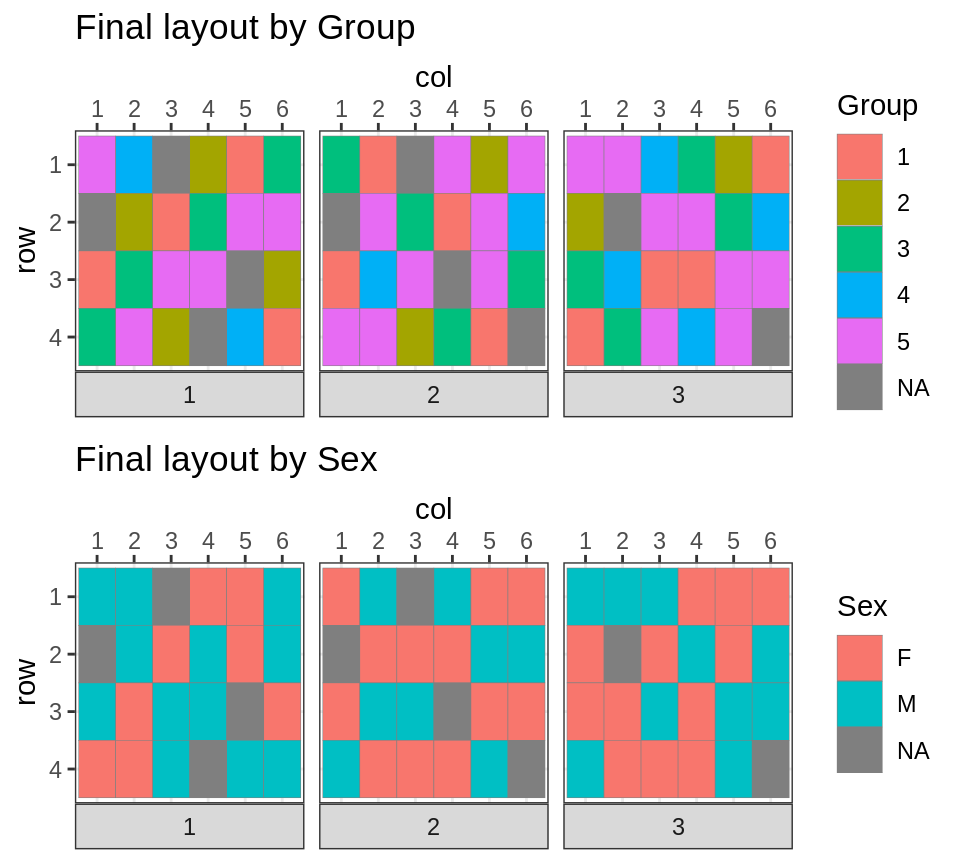

```r
cowplot::plot_grid(
  plotlist = list(
    plot_plate(bc,
      plate = plate, row = row, column = col, .color = Group,
      title = "Final layout by Group"
    ),
    plot_plate(bc,
      plate = plate, row = row, column = col, .color = Sex,
      title = "Final layout by Sex"
    )
  ),
  nrow = 2
)
```

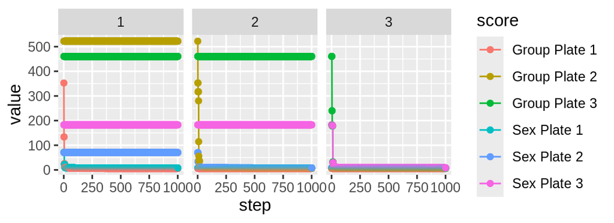

```r
bc$scores_table() |>
  ggplot(aes(step, value, color = score)) +
  geom_line() +
  geom_point() +
  facet_wrap(~ optimization_index)
```

# Full dataset

In the following we use the full data set of longitudinal subject samples that are to be spread across several n-well plates, balanced for treatment group and time point `longitudinal_subject_samples`.

In addition to the normal samples there are also controls to be placed on each plate. These are added after the sample batching step.

For accommodation of samples to plates there are the following control samples available

```r
longitudinal_subject_samples |>
  filter(SampleType != "Sample") |>
  count(SampleType, Group) |>
  gt::gt()
```

| SampleType | Group | n |
| --- | --- | --- |
| Control | Pool | 6 |
| Standard | SpikeIn | 15 |

## Step 1: Batching

We first create a ‘subjects’ dataset.

```r
# get subject data for batching
subjects <- longitudinal_subject_samples |>
  filter(SampleType == "Sample") |>
  count(SubjectID, Group, Sex, Age, name = "nTimePoints") |>
  distinct()

subjects |>
  select(-nTimePoints) |>
  slice(1:5) |>
  gt::gt() |>
  gt::tab_options()
```

| SubjectID | Group | Sex | Age |
| --- | --- | --- | --- |
| P01 | 1 | F | 71 |
| P02 | 1 | M | 74 |
| P03 | 1 | M | 76 |
| P04 | 1 | F | 83 |
| P05 | 2 | M | 79 |

Then we create a batch container for the samples with 3 batches called `plate` that each fit 11 subjects i.e. have 11 virtual `locations`.

For layout scoring we use OSAT score on `Group` and `Sex` variables. We initially assign the samples randomly to the batches and check the layout.

```r
set.seed(42)

bc <- BatchContainer$new(
  dimensions = list("plate" = 3, "locations" = 11)
)

scoring_f <- list(
  group = osat_score_generator(batch_vars = "plate", feature_vars = c("Group")),
  sex = osat_score_generator(batch_vars = "plate", feature_vars = "Sex")
)

bc <- assign_random(bc, subjects)
```

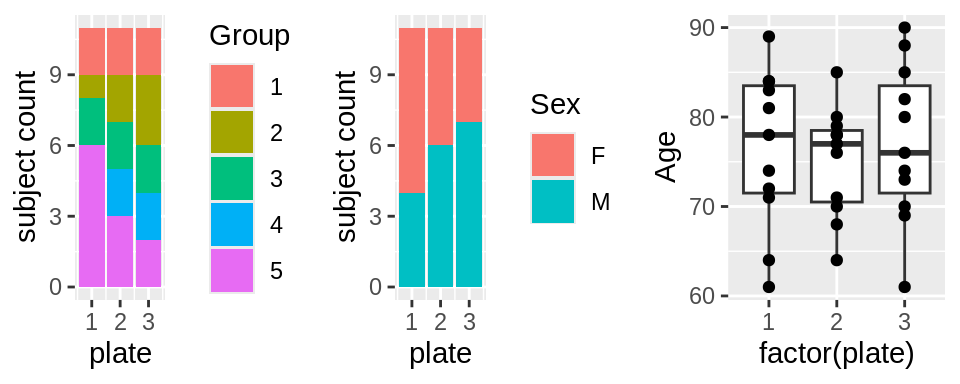

```r
cowplot::plot_grid(
  plotlist = list(
    bc$get_samples() |> ggplot(aes(x = plate, fill = Group)) +
      geom_bar() +
      labs(y = "subject count"),
    bc$get_samples() |> ggplot(aes(x = plate, fill = Sex)) +
      geom_bar() +
      labs(y = "subject count"),
    bc$get_samples() |> ggplot(aes(x = factor(plate), y = Age)) +
      geom_boxplot() +
      geom_point()
  ),
  nrow = 1
)
```

Optimizing the layout with `optimize_design()`

```r
bc <- optimize_design(
  bc,
  scoring = scoring_f,
  n_shuffle = 1,
  acceptance_func = ~ accept_leftmost_improvement(..., tolerance = 0.1),
  max_iter = 150,
  quiet = TRUE
)
```

After optimization the group and sex of samples are equally distributed across all plates. The lower right panel shows the optimization trace of the scores.

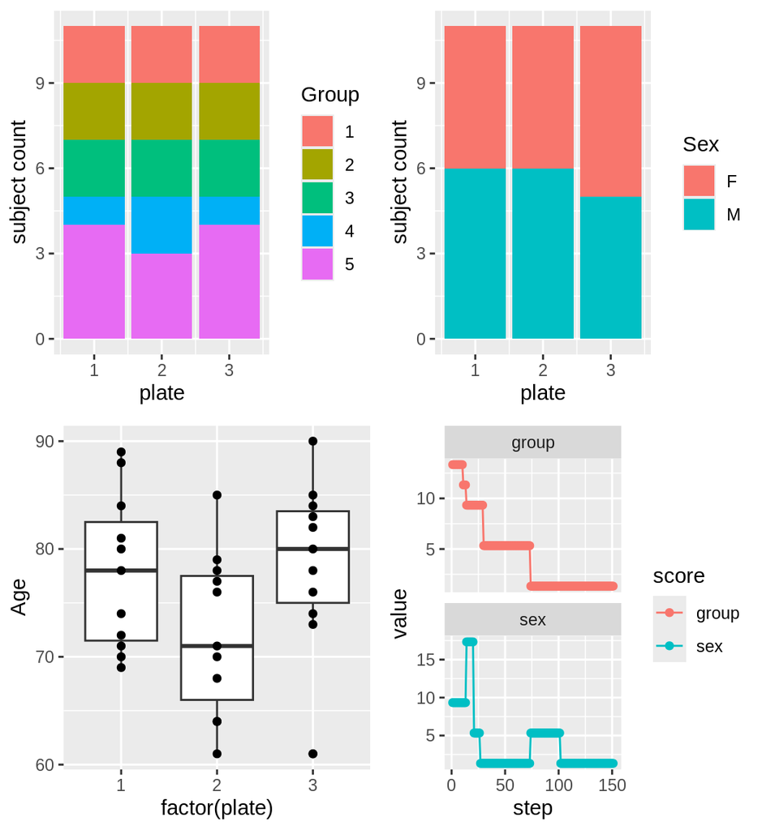

```r
cowplot::plot_grid(
  plotlist = list(
    bc$get_samples() |> ggplot(aes(x = plate, fill = Group)) +
      geom_bar() +
      labs(y = "subject count"),
    bc$get_samples() |> ggplot(aes(x = plate, fill = Sex)) +
      geom_bar() +
      labs(y = "subject count"),
    bc$get_samples() |> ggplot(aes(x = factor(plate), y = Age)) +
      geom_boxplot() +
      geom_point(),
    bc$plot_trace(include_aggregated = TRUE)
  ),
  nrow = 2
)
```

## Step 2: Within plate sample distribution

We start here by creating the batch container for all samples and making an initial assignment. Note there will be empty positions on the plates which we have to add before we assign the samples to the batch container *in order*.

```r
samples_with_plate <- longitudinal_subject_samples |>
  left_join(bc$get_samples() |>
    select(-locations)) |>
  mutate(plate = ifelse(SampleType == "Sample", plate, str_extract(SampleID, ".$")))
# not all plates have same amount of samples
samples_with_plate |> count(plate)
```

```
#> # A tibble: 3 × 2
#>   plate     n
#>   <chr> <int>
#> 1 1        77
#> 2 2        80
#> 3 3        73
```

```r
# add empty wells depending on how full the batch plate is
# column 11 and 12 are left empty: 96 - 16 = 80 samples per plate
samples_with_plate <- samples_with_plate |>
  bind_rows(data.frame(
    SubjectID = "empty",
    SampleID = paste("empty", 1:(3 * 80 - nrow(samples_with_plate))),
    plate = rep(1:3, 80 - (samples_with_plate |> count(plate) |> pull(n))) |>
      as.character()
  ))


# new batch container for step 2
bc <- BatchContainer$new(
  dimensions = list(plate = 3, row = 8, col = 12),
  exclude = crossing(plate = 1:3, row = 1:8, col = 11:12)
)

# assign samples in order of plate
bc <- assign_in_order(
  bc,
  samples_with_plate |>
    arrange(plate) |>
    rename(orig_plate = plate)
)

# check if plate assignment is still correct
bc$get_samples() |>
  summarize(all(plate == orig_plate)) |>
  unlist()
```

```
#> all(plate == orig_plate)
#>                     TRUE
```

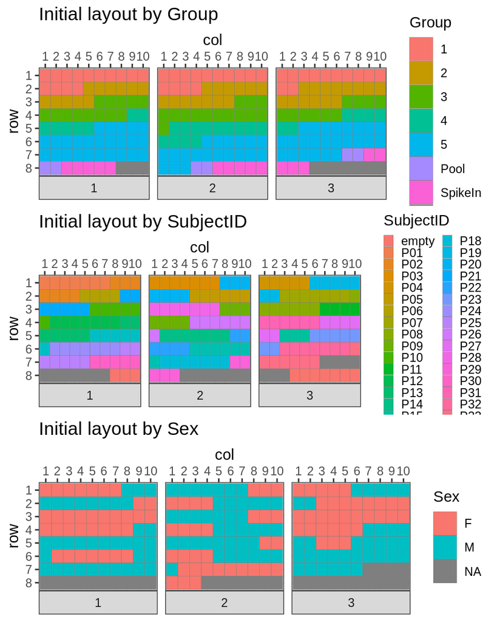

```r
cowplot::plot_grid(
  plotlist = list(
    plot_plate(bc,
      plate = plate, row = row, column = col, .color = Group,
      title = "Initial layout by Group"
    ),
    plot_plate(bc,
      plate = plate, row = row, column = col, .color = SubjectID,
      title = "Initial layout by SubjectID"
    ) +
      theme(legend.key.size = unit(.25, "cm")),
    plot_plate(bc,
      plate = plate, row = row, column = col, .color = Sex,
      title = "Initial layout by Sex"
    )
  ),
  nrow = 3
)
```

```r
bc <- optimize_multi_plate_design(bc,
  within_plate_variables = c("Group", "SubjectID", "Sex"),
  plate = "plate",
  row = "row",
  column = "col",
  n_shuffle = 2,
  max_iter = 1000,
  quiet = TRUE
)
```

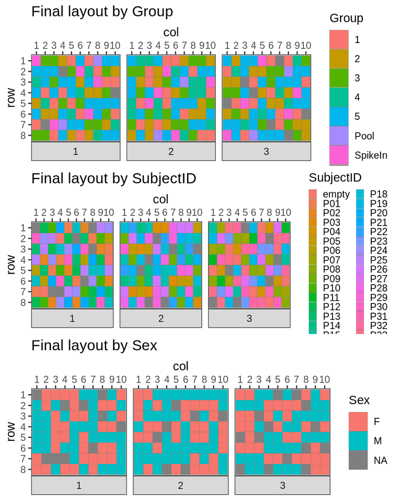

```r
cowplot::plot_grid(
  plotlist = list(
    plot_plate(bc,
      plate = plate, row = row, column = col, .color = Group,
      title = "Final layout by Group"
    ),
    plot_plate(bc,
      plate = plate, row = row, column = col, .color =
        SubjectID, title = "Final layout by SubjectID"
    ) +
      theme(legend.key.size = unit(.25, "cm")),
    plot_plate(bc,
      plate = plate, row = row, column = col, .color = Sex,
      title = "Final layout by Sex"
    )
  ),
  nrow = 3
)
```

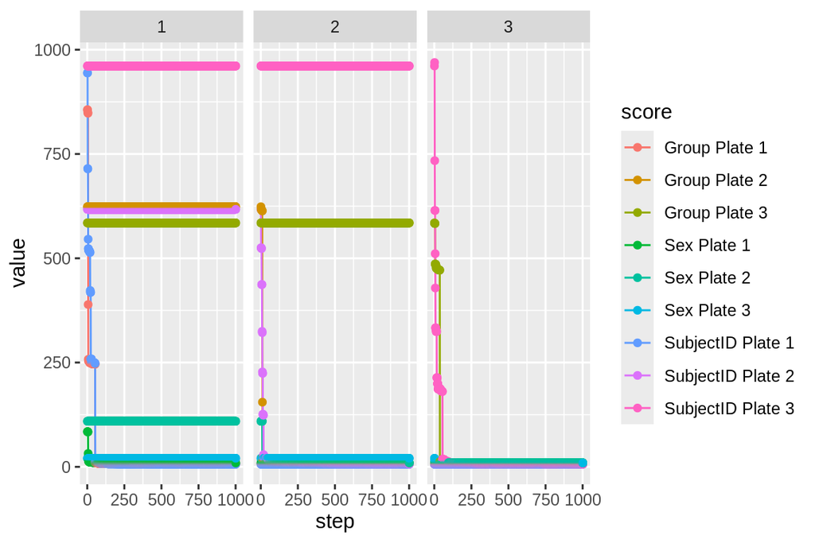

```r
bc$scores_table() |>
  ggplot(aes(step, value, color = score)) +
  geom_line() +
  geom_point() +
  facet_wrap(~ optimization_index)
```